# Tugas Pertemuan 4

# Proses MA(2)

## Pembangkitan model MA(2) dengan 𝜃1 = 0.4 dan 𝜃2 = 0.6 sebanyak 300 data (Manual dan dengan arima.sim)

### Manual

```r
set.seed(131)
wn <- rnorm(300)
```

```r
ma2 <- wn[1:2]
```

```r
for(i in 3:300){
  ma2[i] <- wn[i] + 0.4 * wn[i-1] + 0.6 * wn[i-2]
}

ma2
```

```
##   [1] -0.818846599 -0.543847619  0.312043481  0.128751502  0.181112982
##   [6] -0.363519553  0.749111729  0.372591307 -1.083993055  0.079835735
##  [11] -1.552723134  0.454553273 -0.138615181  1.679135722  1.486490133
##  [16]  0.451084435 -1.305201332 -1.356767589 -0.789306003 -0.595666134
##  [21]  0.294785681 -0.947692603  0.417837259 -2.211691066  0.814769618
##  [26] -0.451839626  0.033856191 -0.771828474 -1.843557151 -0.184471008
##  [31] -1.783979659 -1.443509590 -2.125709588 -2.284720656 -0.585211638
##  [36]  1.415356491  1.591287146  3.804400040  1.160667788  0.135545650
##  [41] -0.756742416 -0.241767111 -0.272801688  0.866633663  0.202067963
##  [46]  1.272261077 -1.506064070  0.281016893 -0.171126190  0.692803934
##  [51]  1.939971684 -1.330539501 -0.439983740  0.117384431  0.035458574
##  [56]  2.015423899  0.391315253  1.571920554  0.168780893 -0.480658481
##  [61]  0.639986577  0.387957534  0.539144828 -0.702485479 -0.686035486
##  [66] -0.197983979 -0.103196939 -0.383750495 -1.637223513 -2.279015902
##  [71] -1.129542707 -1.941540946 -1.373330252 -1.164309551  1.360659019
```

[output cut: 45 more lines]

### Pembangkitan menggunakan arima.sim()

```r
set.seed(131)

ma2_sim <- arima.sim(
  list(order = c(0,0,2), ma = c(0.4,0.6)),
  n = 300
)

ma2_sim
```

```
## Time Series:
## Start = 1
## End = 300
## Frequency = 1
##   [1]  0.312043481  0.128751502  0.181112982 -0.363519553  0.749111729
##   [6]  0.372591307 -1.083993055  0.079835735 -1.552723134  0.454553273
##  [11] -0.138615181  1.679135722  1.486490133  0.451084435 -1.305201332
##  [16] -1.356767589 -0.789306003 -0.595666134  0.294785681 -0.947692603
##  [21]  0.417837259 -2.211691066  0.814769618 -0.451839626  0.033856191
##  [26] -0.771828474 -1.843557151 -0.184471008 -1.783979659 -1.443509590
##  [31] -2.125709588 -2.284720656 -0.585211638  1.415356491  1.591287146
##  [36]  3.804400040  1.160667788  0.135545650 -0.756742416 -0.241767111
##  [41] -0.272801688  0.866633663  0.202067963  1.272261077 -1.506064070
##  [46]  0.281016893 -0.171126190  0.692803934  1.939971684 -1.330539501
##  [51] -0.439983740  0.117384431  0.035458574  2.015423899  0.391315253
```

[output cut: 49 more lines]

## Plot Time Series

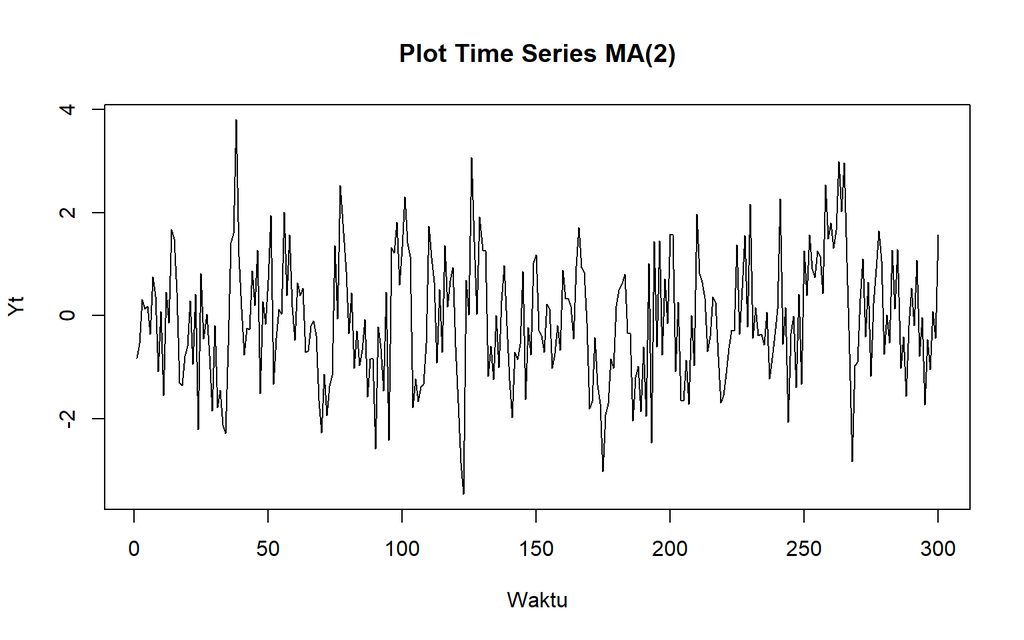

```r
ts.plot(ma2,
        main = "Plot Time Series MA(2)",
        ylab = "Yt",
        xlab = "Waktu")
```

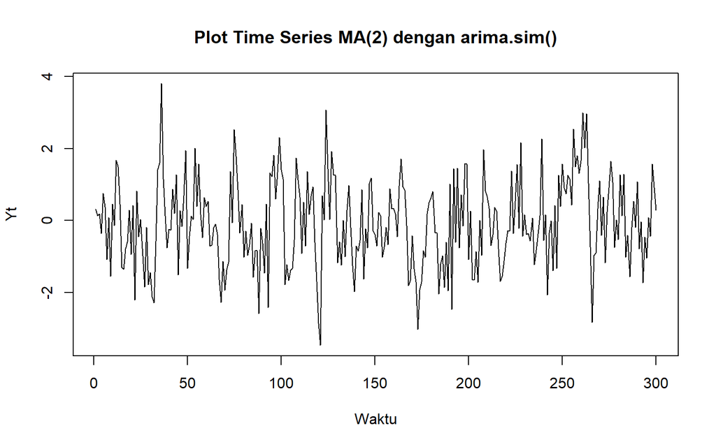

```r
ts.plot(ma2_sim,
        main = "Plot Time Series MA(2) dengan arima.sim()",
        ylab = "Yt",
        xlab = "Waktu")
```

data berfluktuasi di sekitar nilai rata-rata yang relatif konstan dan tidak menunjukkan pola tren naik/turun maupun perubahan varians yang mencolok.

## Plot ACF

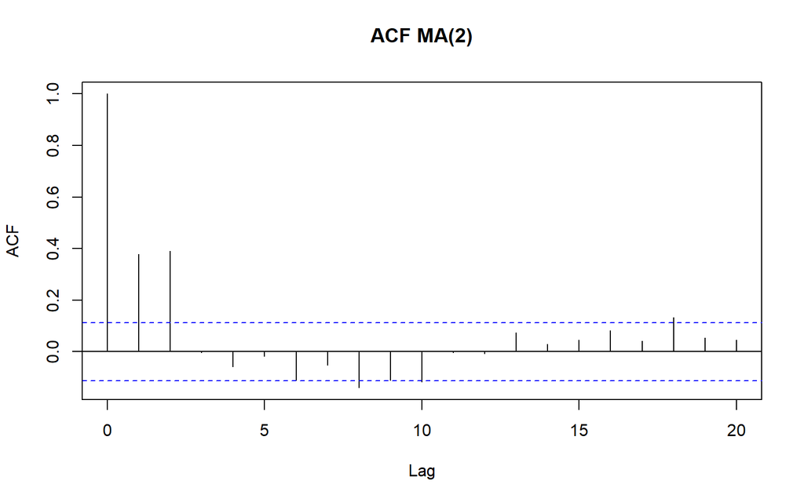

```r
acf(ma2, lag.max = 20,
    main = "ACF MA(2)")
```

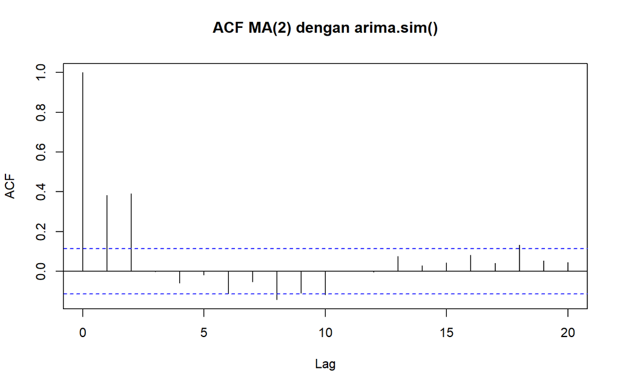

```r
acf(ma2_sim, lag.max = 20,
    main = "ACF MA(2) dengan arima.sim()")
```

korelasi terlihat signifikan terutama pada lag 1 dan lag 2, kemudian setelah lag 2 sebagian besar berada di dalam batas kepercayaan. Pola ini sesuai dengan karakteristik proses MA(2), yaitu ACF terputus setelah lag ke-2.

## Plot PACF

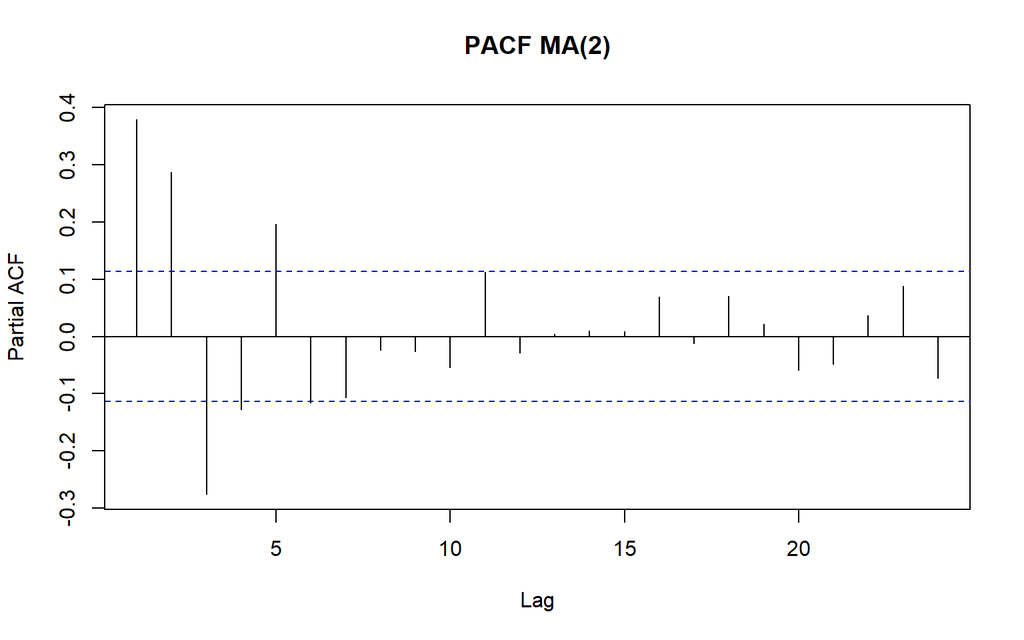

```r
pacf(ma2,
     main = "PACF MA(2)")
```

## Plot EACF

```r
TSA::eacf(ma2)
```

```
## AR/MA
##   0 1 2 3 4 5 6 7 8 9 10 11 12 13
## 0 x x o o o o o x o o o  o  o  o
## 1 x x o o o x o o o x o  o  o  o
## 2 x x o x o o o o o o o  o  o  o
## 3 x x o x o o o o o o o  o  o  o
## 4 x x x x o x o o o o o  o  o  o
## 5 x x x x o o o o o o o  o  o  o
## 6 x x o o x o x x o o o  o  o  o
## 7 x x o o x x x x o o o  o  o  o
```

nilai autokorelasi parsial cenderung menurun/berfluktuasi setelah beberapa lag dan tidak menunjukkan pola yang mengindikasikan adanya tren atau ketidakstasioneran.

### Kesimpulan

Berdasarkan plot time series, ACF, dan PACF, data MA(2) dapat diidentifikasi sebagai data yang stasioner dalam rataan. Hal ini ditunjukkan oleh data yang berfluktuasi di sekitar rata-rata yang relatif konstan tanpa adanya tren, serta ACF yang terputus setelah lag ke-2.

## Scatterplot (Y_t) dengan Y_t−1

```r
yt_ma <- ma2[-1]
```

```r
yt_1_ma <- ma2[-300]
```

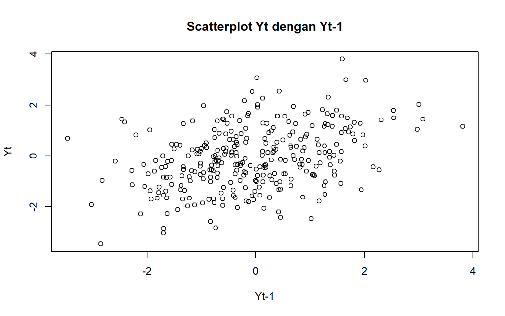

```r
plot(x = yt_1_ma,
     y = yt_ma,
     main = "Scatterplot Yt dengan Yt-1",
     xlab = "Yt-1",
     ylab = "Yt")
```

```r
cor(yt_ma, yt_1_ma)
```

```
## [1] 0.3805014
```

## Scatterplot Y_t dengan Y_t−2

```r
yt_ma2 <- ma2[-c(1,2)]
```

```r
yt_2_ma <- ma2[-c(299,300)]
```

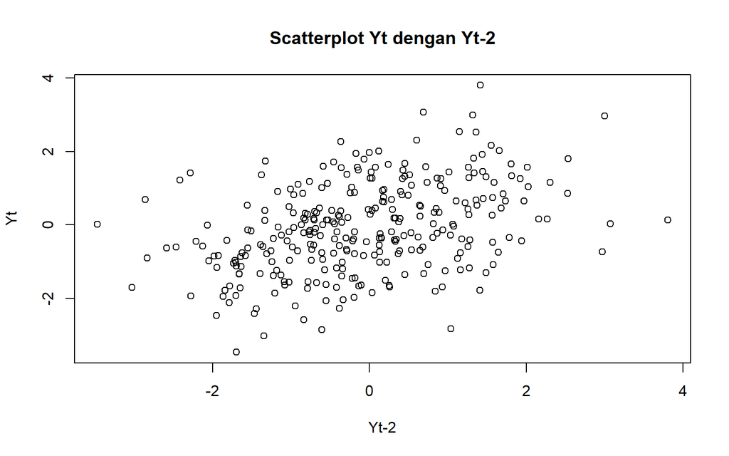

```r
plot(x = yt_2_ma,
     y = yt_ma2,
     main = "Scatterplot Yt dengan Yt-2",
     xlab = "Yt-2",
     ylab = "Yt")
```

```r
cor(yt_ma2, yt_2_ma)
```

```
## [1] 0.3913565
```

## Scatterplot Y_t dengan Y_t−3

```r
yt_ma3 <- ma2[-c(1,2,3)]
```

```r
yt_3_ma <- ma2[-c(298,299,300)]
```

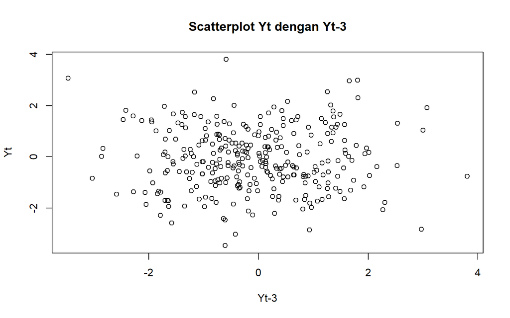

```r
plot(x = yt_3_ma,
     y = yt_ma3,
     main = "Scatterplot Yt dengan Yt-3",
     xlab = "Yt-3",
     ylab = "Yt")
```

```r
cor(yt_ma3, yt_3_ma)
```

```
## [1] -0.002534211
```

## Autokorelasi dari Data Bangkitan

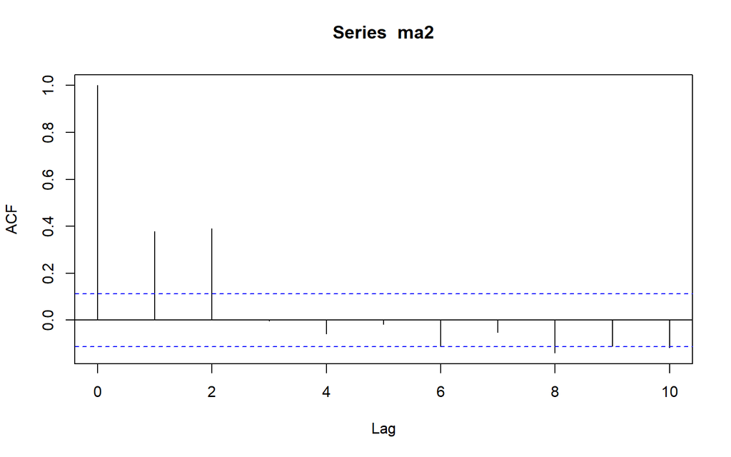

```r
acf(ma2, lag.max = 10)
```

```r
acf_result <- acf(ma2, lag.max = 10, plot = FALSE)

acf_result$acf
```

```
## , , 1
##
##               [,1]
##  [1,]  1.000000000
##  [2,]  0.379066257
##  [3,]  0.389727555
##  [4,] -0.002532103
##  [5,] -0.057196137
##  [6,] -0.017353389
##  [7,] -0.110351169
##  [8,] -0.051738801
##  [9,] -0.139536653
## [10,] -0.109821015
## [11,] -0.115998984
```

## Autokorelasi Teoritis MA(2)

```r
theta1 <- 0.4
theta2 <- 0.6

rho0 <- 1

rho1 <- (theta1 + theta1*theta2) /
        (1 + theta1^2 + theta2^2)

rho2 <- theta2 /
        (1 + theta1^2 + theta2^2)

rho3 <- 0

rho0
```

```
## [1] 1
```

```r
rho1
```

```
## [1] 0.4210526
```

```r
rho2
```

```
## [1] 0.3947368
```

```r
rho3
```

```
## [1] 0
```

# Proses AR(2)

### Manual

```r
set.seed(131)
wn <- rnorm(300)
```

```r
n <- length(wn)
n
```

```
## [1] 300
```

```r
ar <- c(1:n)

ar[1] <- wn[1]
ar[2] <- wn[2]

for(i in 3:n){
  ar[i] <- wn[i] + 0.5*ar[i-1] + 0.2*ar[i-2]
}

ar
```

```
##   [1] -0.81884660 -0.54384762  0.58519736  0.23053303 -0.21779687 -0.27429256
##   [7]  0.92306808  0.46465778 -1.35250769  0.16950417 -0.97793305 -0.13533486
##  [13] -0.05445139  1.34948350  1.46354955  0.29061098 -1.06258058 -0.80306100
##  [19] -0.37103787 -0.84106503 -0.14778610 -1.03161992 -0.01989677 -2.16444328
##  [25]  0.19255474 -0.13105066 -0.84263588 -1.01644432 -1.80336709 -0.49744657
##  [31] -1.96041605 -2.34731469 -2.37379159 -2.85728856 -1.52341168  0.65075447
##  [37]  0.59042028  2.81152011  1.38821304  0.01451318  0.10629437  0.63086306
##  [43] -0.05887368  0.77670712  0.54399670  1.22465089 -1.20431446  0.21557887
##  [49]  0.62194153  0.40120093  1.79310571 -0.96926187 -0.66844173  0.97391691
##  [55]  0.11339179  1.46166041  0.80467835  1.52001521  0.72888471 -0.23059603
##  [61]  1.14531722  1.00798648  0.41071971 -0.45546179 -0.29325268  0.14081498
##  [67] -0.15425402 -0.59343032 -1.64739637 -2.36678820 -1.28075626 -2.29348119
##  [73] -2.44359420 -1.72067470  0.65209679 -0.86145202  1.36726053  2.13439121
##  [79]  0.54582366 -0.30408165  1.27545535 -0.36863968 -0.63157509 -0.50687585
##  [85] -0.58176735 -0.31329128 -1.76374853 -1.23260109 -0.79329433 -3.12582103
```

[output cut: 35 more lines]

### arima.sim

```r
ar2 <- arima.sim(list(order=c(2,0,0), ar=c(0.5,0.2)), n=300)
ar2
```

```
## Time Series:
## Start = 1
## End = 300
## Frequency = 1
##   [1]  0.799705221  0.235668338  0.070689622 -1.059580642  0.002871801
##   [6]  1.409249621  1.414793986  0.010098888  0.481574740  2.301804131
##  [11]  0.643887459  1.898712467 -0.052845577  0.647028661 -0.440319062
##  [16]  1.105582121  0.076024653  1.458309512  1.014067465  1.110162964
##  [21]  1.520950008  0.826130896  0.886550052  0.886223575 -0.345060453
##  [26] -1.074122613 -1.931214166 -1.393045817 -0.446087136 -1.139523868
##  [31] -1.672173407 -2.887025836 -3.300020010 -0.921657151  0.691404859
##  [36] -0.478207983  1.111594278  2.497343611  0.881334398  1.825343091
##  [41] -0.653567715  1.503273195 -0.712692172 -0.233628764 -0.262066184
##  [46] -1.323613086 -1.003245386 -1.170467194  0.559646390 -1.340272269
##  [51] -1.157363694 -1.626828968  0.269954641 -0.229226524  0.330604299
```

[output cut: 49 more lines]

## Buat plot time series, plot ACF, plot PACF dan plot EACF. Idenifikasi apakah data tersebut stasioner

### Plot Time Series

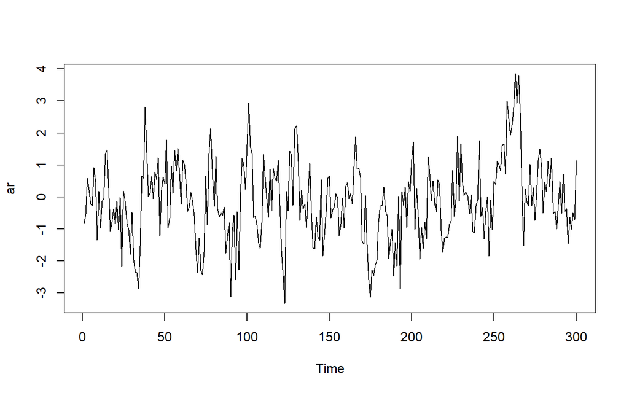

```r
ts.plot(ar)
```

Plot time series menunjukkan data berfluktuasi di sekitar nilai rata-rata yang relatif konstan. Tidak terlihat adanya tren naik atau turun yang sistematis.

### Plot ACF

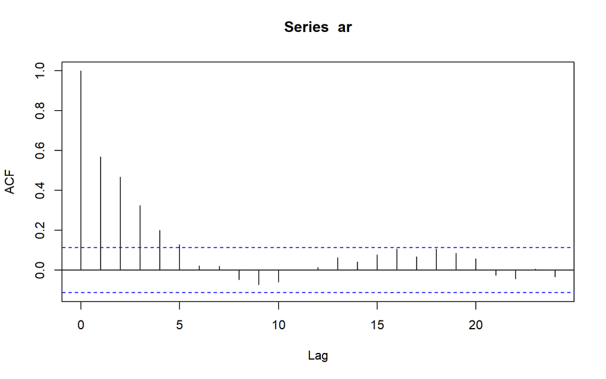

```r
acf(ar)
```

Plot ACF menunjukkan autokorelasi yang menurun secara bertahap dan kemudian mendekati nol. Tidak ada pola ACF yang bertahan sangat tinggi pada banyak lag, sehingga tidak mengindikasikan adanya ketidakstasioneran.

### Plot PACF

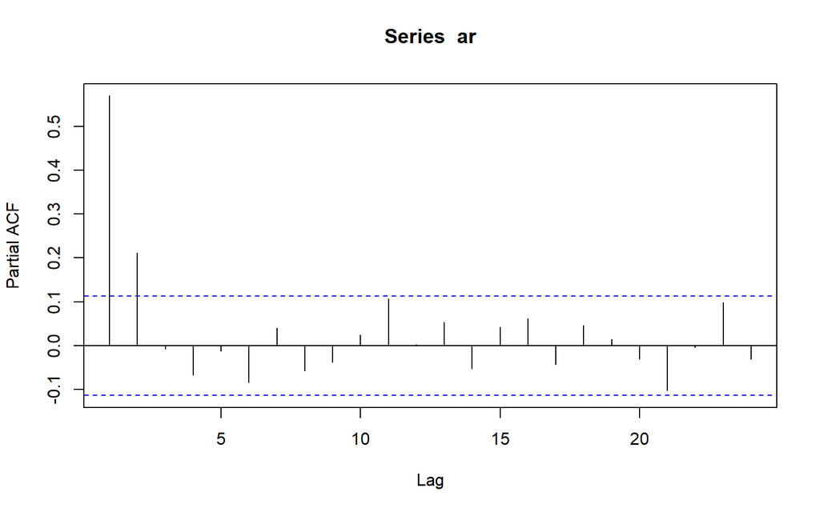

```r
pacf(ar)
```

Plot PACF menunjukkan nilai yang besar pada beberapa lag awal, kemudian sebagian besar nilai berada di dalam batas kepercayaan.

### Plot EACF

```r
TSA::eacf(ar)
```

```
## AR/MA
##   0 1 2 3 4 5 6 7 8 9 10 11 12 13
## 0 x x x x x o o o o o o  o  o  o
## 1 x o o o o x o o o o o  o  o  o
## 2 o x o o o o o o o o o  o  o  o
## 3 x x o o o o o o o o o  o  o  o
## 4 x x o x o o o o o o o  o  o  o
## 5 x x x o o o o o o o o  o  o  o
## 6 x x x x o o x o o o o  o  o  o
## 7 x x x x o o x o o o o  o  o  o
```

Plot EACF juga memberikan pola yang masih konsisten dengan proses AR, bukan pola yang menunjukkan adanya differencing.

### Kesimpulan

Berdasarkan plot time series, ACF, PACF, dan EACF, data dapat diidentifikasi sebagai data yang stasioner dalam rataan. Hal ini ditunjukkan oleh data yang berfluktuasi di sekitar nilai rata-rata yang relatif konstan tanpa adanya tren, serta ACF yang menurun secara bertahap menuju nol. Dengan demikian, data AR(2) tidak memerlukan proses differencing.

## Buat scatterplot antara 𝑌𝑡 dengan 𝑌𝑡−1, 𝑌𝑡 dengan 𝑌𝑡−2 serta 𝑌𝑡dengan 𝑌𝑡−3

### Korelasi antara Y_t dengan Y_t−1

```r
yt_ar <- ar[-1]
yt_ar
```

```
##   [1] -0.54384762  0.58519736  0.23053303 -0.21779687 -0.27429256  0.92306808
##   [7]  0.46465778 -1.35250769  0.16950417 -0.97793305 -0.13533486 -0.05445139
##  [13]  1.34948350  1.46354955  0.29061098 -1.06258058 -0.80306100 -0.37103787
##  [19] -0.84106503 -0.14778610 -1.03161992 -0.01989677 -2.16444328  0.19255474
##  [25] -0.13105066 -0.84263588 -1.01644432 -1.80336709 -0.49744657 -1.96041605
##  [31] -2.34731469 -2.37379159 -2.85728856 -1.52341168  0.65075447  0.59042028
##  [37]  2.81152011  1.38821304  0.01451318  0.10629437  0.63086306 -0.05887368
##  [43]  0.77670712  0.54399670  1.22465089 -1.20431446  0.21557887  0.62194153
##  [49]  0.40120093  1.79310571 -0.96926187 -0.66844173  0.97391691  0.11339179
##  [55]  1.46166041  0.80467835  1.52001521  0.72888471 -0.23059603  1.14531722
##  [61]  1.00798648  0.41071971 -0.45546179 -0.29325268  0.14081498 -0.15425402
##  [67] -0.59343032 -1.64739637 -2.36678820 -1.28075626 -2.29348119 -2.44359420
##  [73] -1.72067470  0.65209679 -0.86145202  1.36726053  2.13439121  0.54582366
##  [79] -0.30408165  1.27545535 -0.36863968 -0.63157509 -0.50687585 -0.58176735
##  [85] -0.31329128 -1.76374853 -1.23260109 -0.79329433 -3.12582103 -1.05185051
```

[output cut: 35 more lines]

```r
yt_1_ar <- ar[-300]
yt_1_ar
```

```
##   [1] -0.81884660 -0.54384762  0.58519736  0.23053303 -0.21779687 -0.27429256
##   [7]  0.92306808  0.46465778 -1.35250769  0.16950417 -0.97793305 -0.13533486
##  [13] -0.05445139  1.34948350  1.46354955  0.29061098 -1.06258058 -0.80306100
##  [19] -0.37103787 -0.84106503 -0.14778610 -1.03161992 -0.01989677 -2.16444328
##  [25]  0.19255474 -0.13105066 -0.84263588 -1.01644432 -1.80336709 -0.49744657
##  [31] -1.96041605 -2.34731469 -2.37379159 -2.85728856 -1.52341168  0.65075447
##  [37]  0.59042028  2.81152011  1.38821304  0.01451318  0.10629437  0.63086306
##  [43] -0.05887368  0.77670712  0.54399670  1.22465089 -1.20431446  0.21557887
##  [49]  0.62194153  0.40120093  1.79310571 -0.96926187 -0.66844173  0.97391691
##  [55]  0.11339179  1.46166041  0.80467835  1.52001521  0.72888471 -0.23059603
##  [61]  1.14531722  1.00798648  0.41071971 -0.45546179 -0.29325268  0.14081498
##  [67] -0.15425402 -0.59343032 -1.64739637 -2.36678820 -1.28075626 -2.29348119
##  [73] -2.44359420 -1.72067470  0.65209679 -0.86145202  1.36726053  2.13439121
##  [79]  0.54582366 -0.30408165  1.27545535 -0.36863968 -0.63157509 -0.50687585
##  [85] -0.58176735 -0.31329128 -1.76374853 -1.23260109 -0.79329433 -3.12582103
```

[output cut: 35 more lines]

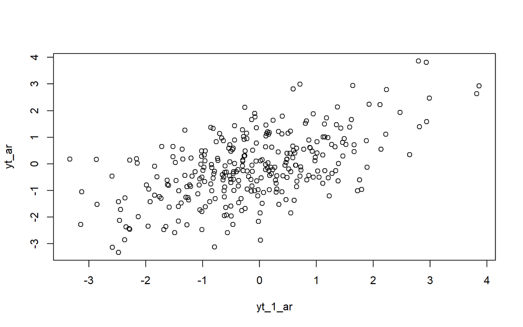

```r
plot(y=yt_ar,x=yt_1_ar)
```

```r
cor(yt_ar,yt_1_ar)
```

```
## [1] 0.5707677
```

### Korelasi antara Y_t dengan Y_t−2

```r
yt_ar2 <- ar[-c(1,2)]
yt_ar2
```

```
##   [1]  0.58519736  0.23053303 -0.21779687 -0.27429256  0.92306808  0.46465778
##   [7] -1.35250769  0.16950417 -0.97793305 -0.13533486 -0.05445139  1.34948350
##  [13]  1.46354955  0.29061098 -1.06258058 -0.80306100 -0.37103787 -0.84106503
##  [19] -0.14778610 -1.03161992 -0.01989677 -2.16444328  0.19255474 -0.13105066
##  [25] -0.84263588 -1.01644432 -1.80336709 -0.49744657 -1.96041605 -2.34731469
##  [31] -2.37379159 -2.85728856 -1.52341168  0.65075447  0.59042028  2.81152011
##  [37]  1.38821304  0.01451318  0.10629437  0.63086306 -0.05887368  0.77670712
##  [43]  0.54399670  1.22465089 -1.20431446  0.21557887  0.62194153  0.40120093
##  [49]  1.79310571 -0.96926187 -0.66844173  0.97391691  0.11339179  1.46166041
##  [55]  0.80467835  1.52001521  0.72888471 -0.23059603  1.14531722  1.00798648
##  [61]  0.41071971 -0.45546179 -0.29325268  0.14081498 -0.15425402 -0.59343032
##  [67] -1.64739637 -2.36678820 -1.28075626 -2.29348119 -2.44359420 -1.72067470
##  [73]  0.65209679 -0.86145202  1.36726053  2.13439121  0.54582366 -0.30408165
##  [79]  1.27545535 -0.36863968 -0.63157509 -0.50687585 -0.58176735 -0.31329128
##  [85] -1.76374853 -1.23260109 -0.79329433 -3.12582103 -1.05185051 -0.56525818
```

[output cut: 35 more lines]

```r
yt_2_ar <- ar[-c(299,300)]
yt_2_ar
```

```
##   [1] -0.81884660 -0.54384762  0.58519736  0.23053303 -0.21779687 -0.27429256
##   [7]  0.92306808  0.46465778 -1.35250769  0.16950417 -0.97793305 -0.13533486
##  [13] -0.05445139  1.34948350  1.46354955  0.29061098 -1.06258058 -0.80306100
##  [19] -0.37103787 -0.84106503 -0.14778610 -1.03161992 -0.01989677 -2.16444328
##  [25]  0.19255474 -0.13105066 -0.84263588 -1.01644432 -1.80336709 -0.49744657
##  [31] -1.96041605 -2.34731469 -2.37379159 -2.85728856 -1.52341168  0.65075447
##  [37]  0.59042028  2.81152011  1.38821304  0.01451318  0.10629437  0.63086306
##  [43] -0.05887368  0.77670712  0.54399670  1.22465089 -1.20431446  0.21557887
##  [49]  0.62194153  0.40120093  1.79310571 -0.96926187 -0.66844173  0.97391691
##  [55]  0.11339179  1.46166041  0.80467835  1.52001521  0.72888471 -0.23059603
##  [61]  1.14531722  1.00798648  0.41071971 -0.45546179 -0.29325268  0.14081498
##  [67] -0.15425402 -0.59343032 -1.64739637 -2.36678820 -1.28075626 -2.29348119
##  [73] -2.44359420 -1.72067470  0.65209679 -0.86145202  1.36726053  2.13439121
##  [79]  0.54582366 -0.30408165  1.27545535 -0.36863968 -0.63157509 -0.50687585
##  [85] -0.58176735 -0.31329128 -1.76374853 -1.23260109 -0.79329433 -3.12582103
```

[output cut: 35 more lines]

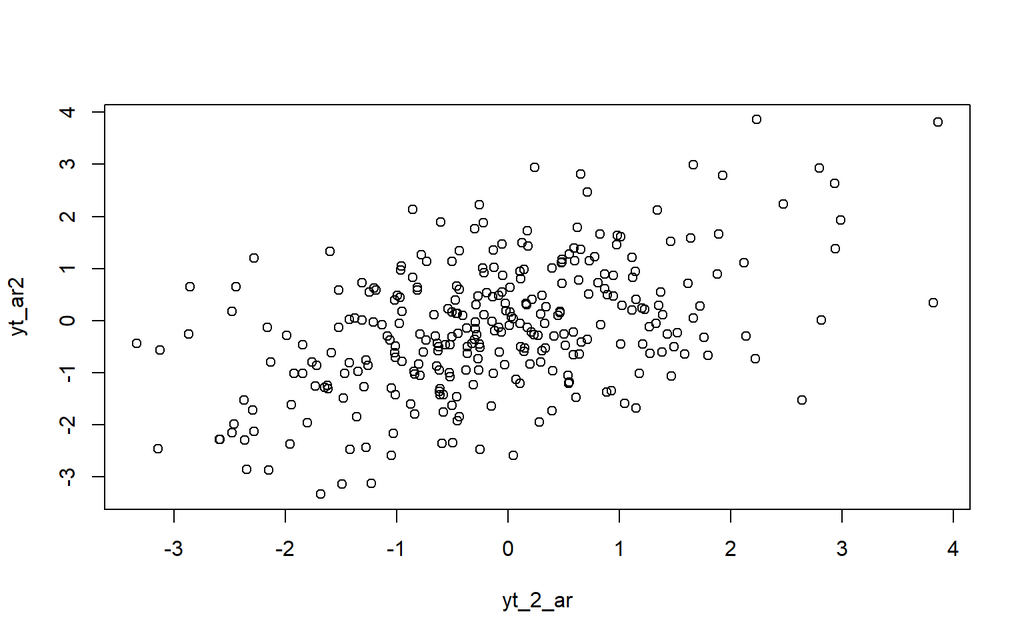

```r
plot(y=yt_ar2,x=yt_2_ar)
```

```r
cor(yt_ar2,yt_2_ar)
```

```
## [1] 0.468204
```

### Korelasi antara Y_t dengan Y_t−3

```r
yt_ar3 <- ar[-c(1,2,3)]
yt_ar3
```

```
##   [1]  0.23053303 -0.21779687 -0.27429256  0.92306808  0.46465778 -1.35250769
##   [7]  0.16950417 -0.97793305 -0.13533486 -0.05445139  1.34948350  1.46354955
##  [13]  0.29061098 -1.06258058 -0.80306100 -0.37103787 -0.84106503 -0.14778610
##  [19] -1.03161992 -0.01989677 -2.16444328  0.19255474 -0.13105066 -0.84263588
##  [25] -1.01644432 -1.80336709 -0.49744657 -1.96041605 -2.34731469 -2.37379159
##  [31] -2.85728856 -1.52341168  0.65075447  0.59042028  2.81152011  1.38821304
##  [37]  0.01451318  0.10629437  0.63086306 -0.05887368  0.77670712  0.54399670
##  [43]  1.22465089 -1.20431446  0.21557887  0.62194153  0.40120093  1.79310571
##  [49] -0.96926187 -0.66844173  0.97391691  0.11339179  1.46166041  0.80467835
##  [55]  1.52001521  0.72888471 -0.23059603  1.14531722  1.00798648  0.41071971
##  [61] -0.45546179 -0.29325268  0.14081498 -0.15425402 -0.59343032 -1.64739637
##  [67] -2.36678820 -1.28075626 -2.29348119 -2.44359420 -1.72067470  0.65209679
##  [73] -0.86145202  1.36726053  2.13439121  0.54582366 -0.30408165  1.27545535
##  [79] -0.36863968 -0.63157509 -0.50687585 -0.58176735 -0.31329128 -1.76374853
##  [85] -1.23260109 -0.79329433 -3.12582103 -1.05185051 -0.56525818 -2.59298698
```

[output cut: 35 more lines]

```r
yt_3_ar <- ar[-c(298,299,300)]
yt_3_ar
```

```
##   [1] -0.81884660 -0.54384762  0.58519736  0.23053303 -0.21779687 -0.27429256
##   [7]  0.92306808  0.46465778 -1.35250769  0.16950417 -0.97793305 -0.13533486
##  [13] -0.05445139  1.34948350  1.46354955  0.29061098 -1.06258058 -0.80306100
##  [19] -0.37103787 -0.84106503 -0.14778610 -1.03161992 -0.01989677 -2.16444328
##  [25]  0.19255474 -0.13105066 -0.84263588 -1.01644432 -1.80336709 -0.49744657
##  [31] -1.96041605 -2.34731469 -2.37379159 -2.85728856 -1.52341168  0.65075447
##  [37]  0.59042028  2.81152011  1.38821304  0.01451318  0.10629437  0.63086306
##  [43] -0.05887368  0.77670712  0.54399670  1.22465089 -1.20431446  0.21557887
##  [49]  0.62194153  0.40120093  1.79310571 -0.96926187 -0.66844173  0.97391691
##  [55]  0.11339179  1.46166041  0.80467835  1.52001521  0.72888471 -0.23059603
##  [61]  1.14531722  1.00798648  0.41071971 -0.45546179 -0.29325268  0.14081498
##  [67] -0.15425402 -0.59343032 -1.64739637 -2.36678820 -1.28075626 -2.29348119
##  [73] -2.44359420 -1.72067470  0.65209679 -0.86145202  1.36726053  2.13439121
##  [79]  0.54582366 -0.30408165  1.27545535 -0.36863968 -0.63157509 -0.50687585
##  [85] -0.58176735 -0.31329128 -1.76374853 -1.23260109 -0.79329433 -3.12582103
```

[output cut: 35 more lines]

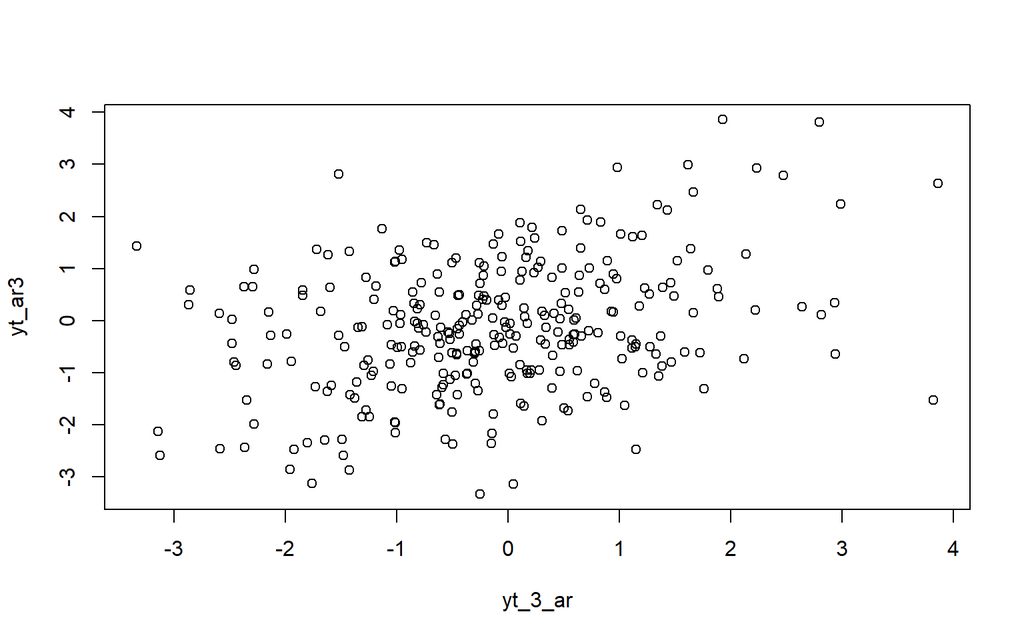

```r
plot(y=yt_ar3,x=yt_3_ar)
```

```r
cor(yt_ar3,yt_3_ar)
```

```
## [1] 0.3266559
```

## Hitung autokorelasi masing masing baik dari data bangkitan maupun secara teoritis

### Autokorelasi dari data bangkitan

```r
acf_ar <- acf(ar, lag.max = 3, plot = FALSE)

acf_ar$acf
```

```
## , , 1
##
##           [,1]
## [1,] 1.0000000
## [2,] 0.5694647
## [3,] 0.4668899
## [4,] 0.3255104
```

```r
rho1_data <- acf_ar$acf[2]
rho2_data <- acf_ar$acf[3]
rho3_data <- acf_ar$acf[4]

rho1_data
```

```
## [1] 0.5694647
```

```r
rho2_data
```

```
## [1] 0.4668899
```

```r
rho3_data
```

```
## [1] 0.3255104
```

### Autokorelasi secara teoritis

```r
phi1 <- 0.5
phi2 <- 0.2

rho0 <- 1

rho1_teori <- phi1 / (1 - phi2)

rho2_teori <- phi1 * rho1_teori + phi2 * rho0

rho3_teori <- phi1 * rho2_teori + phi2 * rho1_teori

rho1_teori
```

```
## [1] 0.625
```

```r
rho2_teori
```

```
## [1] 0.5125
```

```r
rho3_teori
```

```
## [1] 0.38125
```

### Perbandingan

```r
data_autokorelasi <- c(
  rho1_data,
  rho2_data,
  rho3_data
)

teori_autokorelasi <- c(
  rho1_teori,
  rho2_teori,
  rho3_teori
)

hasil <- data.frame(
  Lag = 1:3,
  Data_Bangkitan = data_autokorelasi,
  Teoritis = teori_autokorelasi
)

hasil
```

```
##   Lag Data_Bangkitan Teoritis
## 1   1      0.5694647  0.62500
## 2   2      0.4668899  0.51250
## 3   3      0.3255104  0.38125
```

# Proses ARMA(2,2)

## Bangkitkan model ARMA(2,2) dengan 𝜃1 = 0.4, 𝜃2 = 0.6 ,𝜙1 = 0.5 dan 𝜙2 = 0.2 sebanyak 300 data (Manual dan arima.sim)

### Manual

```r
set.seed(131)
wn <- rnorm(300)
```

```r
n <- length(wn)

arma22 <- c(1:n)

arma22[1] <- wn[1]
arma22[2] <- wn[2]
```

```r
for(i in 3:n){
  arma22[i] <- 0.5*arma22[i-1] +
                0.2*arma22[i-2] +
                0.4*wn[i-1] +
                0.6*wn[i-2] +
                wn[i]
}

arma22
```

```
##   [1] -0.818846599 -0.543847619 -0.123649649 -0.041842846  0.135461629
##   [6] -0.304157307  0.624125402  0.623822547 -0.647256701 -0.119028106
##  [11] -1.741688527 -0.440096612 -0.707001192  1.237615803  1.963897796
##  [16]  1.680556494 -0.072143526 -1.056728053 -1.332098735 -1.473061112
##  [21] -0.708164622 -1.596387137 -0.521989233 -2.791963110 -0.685609784
##  [26] -1.353037140 -0.779784335 -1.432328070 -2.715678053 -1.828775649
##  [31] -3.241503094 -3.430016266 -4.489018340 -5.215233079 -4.090631845
##  [36] -1.673006047 -0.063342247  3.438127707  2.867063192  2.256702787
##  [41]  0.945021616  0.682084255  0.257244763  1.131672895  0.819353363
##  [46]  1.908272338 -0.388057229  0.468642746 -0.014416263  0.779324351
##  [51]  2.326750607 -0.011299327  0.019716717  0.124982924  0.101893379
##  [56]  2.091367174  1.457377515  2.718882746  1.819697769  0.972966953
##  [61]  1.490409607  1.327755728  1.501104614  0.313617974 -0.229005577
##  [66] -0.249763173 -0.273879641 -0.570642949 -1.977320916 -3.381804950
##  [71] -3.215909365 -4.225856619 -4.129440435 -4.074201092 -1.502329614
```

[output cut: 45 more lines]

### arima.sim

```r
set.seed(131)

arma22_sim <- arima.sim(
  list(order=c(2,0,2),
       ar=c(0.5,0.2),
       ma=c(0.4,0.6)),
  n=300
)

arma22_sim
```

```
## Time Series:
## Start = 1
## End = 300
## Frequency = 1
##   [1] -1.431841002 -2.715306738 -1.828492578 -3.241287295 -3.429851753
##   [6] -4.488892924 -5.215137468 -4.090558957 -1.672950481 -0.063299886
##  [11]  3.438160001  2.867087811  2.256721555  0.945035924  0.682095163
##  [16]  0.257253078  1.131679234  0.819358196  1.908276022 -0.388054420
##  [21]  0.468644887 -0.014414631  0.779325595  2.326751556 -0.011298604
##  [26]  0.019717269  0.124983344  0.101893700  2.091367418  1.457377701
##  [31]  2.718882888  1.819697877  0.972967035  1.490409670  1.327755776
##  [36]  1.501104650  0.313618002 -0.229005556 -0.249763156 -0.273879628
##  [41] -0.570642940 -1.977320909 -3.381804945 -3.215909361 -4.225856616
##  [46] -4.129440433 -4.074201090 -1.502329613 -1.633018121  1.413937794
##  [51]  2.164424210  2.219936457  1.194882536  1.481316883 -0.040906528
```

[output cut: 49 more lines]

## Buat plot time series, plot ACF, plot PACF dan plot EACF. Identifikasi apakah data tersebut stasioner

### Plot Time Series

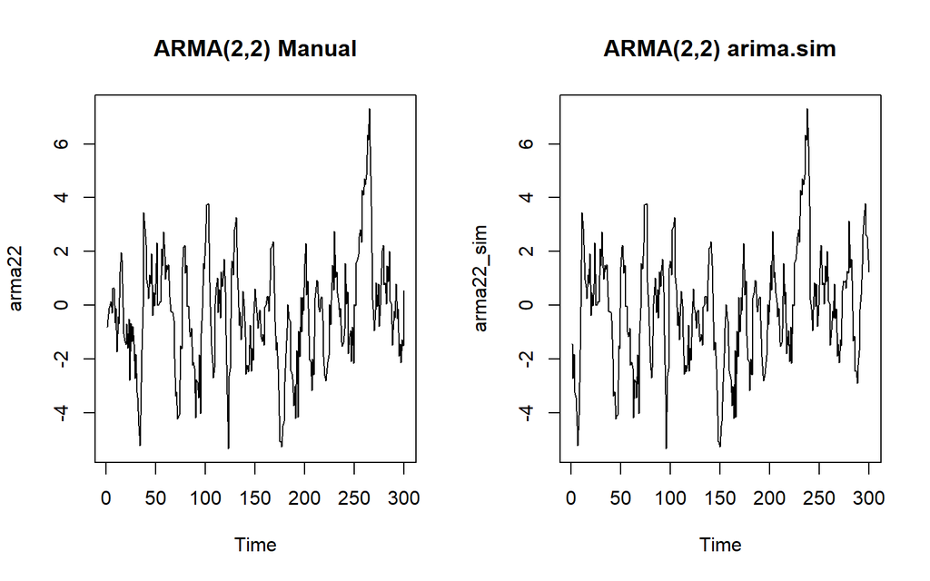

```r
par(mfrow = c(1, 2))

ts.plot(arma22,
        main="ARMA(2,2) Manual")

ts.plot(arma22_sim,
        main="ARMA(2,2) arima.sim")
```

```r
par(mfrow = c(1, 1))
```

Pada plot time series ARMA(2,2) manual maupun arima.sim, data terlihat berfluktuasi di sekitar nilai rata-rata yang relatif konstan. Tidak terlihat adanya pola tren naik atau turun yang sistematis. Varians data juga relatif stabil sepanjang waktu.

### Plot ACF

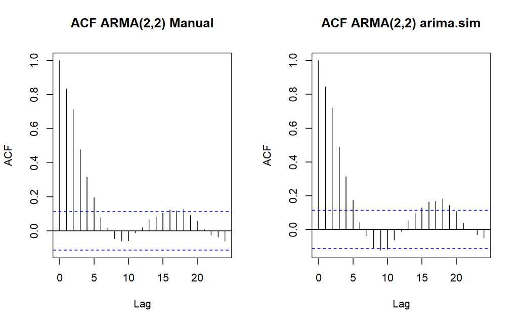

```r
par(mfrow = c(1, 2))

acf(arma22,
    main="ACF ARMA(2,2) Manual")

acf(arma22_sim,
    main="ACF ARMA(2,2) arima.sim")
```

```r
par(mfrow = c(1, 1))
```

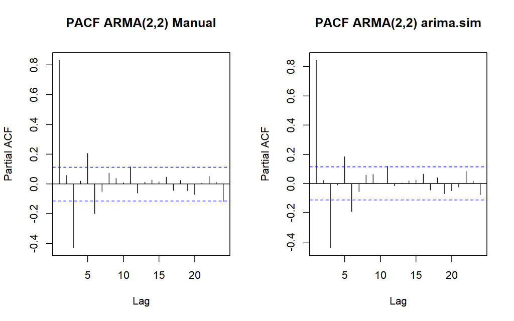

```r
par(mfrow = c(1, 2))

pacf(arma22,
     main="PACF ARMA(2,2) Manual")

pacf(arma22_sim,
     main="PACF ARMA(2,2) arima.sim")
```

```r
par(mfrow = c(1, 1))
```

### Plot EACF

```r
TSA::eacf(arma22)
```

```
## AR/MA
##   0 1 2 3 4 5 6 7 8 9 10 11 12 13
## 0 x x x x x o o o o o o  o  o  o
## 1 o x o o x o o x o o o  o  o  o
## 2 x x x o x o x x o o o  o  o  o
## 3 o x x o x o x o o o o  o  o  o
## 4 o x x x x o o o o o o  o  o  o
## 5 x x x x x x x o o o o  o  o  o
## 6 x x x x x o x o o o o  o  o  o
## 7 x x x o x o x o o o o  o  o  o
```

## Buat scatterplot antara 𝑌𝑡 dengan 𝑌𝑡−1, 𝑌𝑡 dengan 𝑌𝑡−2 serta 𝑌𝑡 dengan 𝑌𝑡−3

### Korelasi antara Y_t dengan Y_t−1

```r
yt_arma <- arma22[-1]
yt_arma
```

```
##   [1] -0.543847619 -0.123649649 -0.041842846  0.135461629 -0.304157307
##   [6]  0.624125402  0.623822547 -0.647256701 -0.119028106 -1.741688527
##  [11] -0.440096612 -0.707001192  1.237615803  1.963897796  1.680556494
##  [16] -0.072143526 -1.056728053 -1.332098735 -1.473061112 -0.708164622
##  [21] -1.596387137 -0.521989233 -2.791963110 -0.685609784 -1.353037140
##  [26] -0.779784335 -1.432328070 -2.715678053 -1.828775649 -3.241503094
##  [31] -3.430016266 -4.489018340 -5.215233079 -4.090631845 -1.673006047
##  [36] -0.063342247  3.438127707  2.867063192  2.256702787  0.945021616
##  [41]  0.682084255  0.257244763  1.131672895  0.819353363  1.908272338
##  [46] -0.388057229  0.468642746 -0.014416263  0.779324351  2.326750607
##  [51] -0.011299327  0.019716717  0.124982924  0.101893379  2.091367174
##  [56]  1.457377515  2.718882746  1.819697769  0.972966953  1.490409607
##  [61]  1.327755728  1.501104614  0.313617974 -0.229005577 -0.249763173
##  [66] -0.273879641 -0.570642949 -1.977320916 -3.381804950 -3.215909365
##  [71] -4.225856619 -4.129440435 -4.074201092 -1.502329614 -1.633018122
```

[output cut: 45 more lines]

```r
yt_1_arma <- arma22[-300]
yt_1_arma
```

```
##   [1] -0.818846599 -0.543847619 -0.123649649 -0.041842846  0.135461629
##   [6] -0.304157307  0.624125402  0.623822547 -0.647256701 -0.119028106
##  [11] -1.741688527 -0.440096612 -0.707001192  1.237615803  1.963897796
##  [16]  1.680556494 -0.072143526 -1.056728053 -1.332098735 -1.473061112
##  [21] -0.708164622 -1.596387137 -0.521989233 -2.791963110 -0.685609784
##  [26] -1.353037140 -0.779784335 -1.432328070 -2.715678053 -1.828775649
##  [31] -3.241503094 -3.430016266 -4.489018340 -5.215233079 -4.090631845
##  [36] -1.673006047 -0.063342247  3.438127707  2.867063192  2.256702787
##  [41]  0.945021616  0.682084255  0.257244763  1.131672895  0.819353363
##  [46]  1.908272338 -0.388057229  0.468642746 -0.014416263  0.779324351
##  [51]  2.326750607 -0.011299327  0.019716717  0.124982924  0.101893379
##  [56]  2.091367174  1.457377515  2.718882746  1.819697769  0.972966953
##  [61]  1.490409607  1.327755728  1.501104614  0.313617974 -0.229005577
##  [66] -0.249763173 -0.273879641 -0.570642949 -1.977320916 -3.381804950
##  [71] -3.215909365 -4.225856619 -4.129440435 -4.074201092 -1.502329614
```

[output cut: 45 more lines]

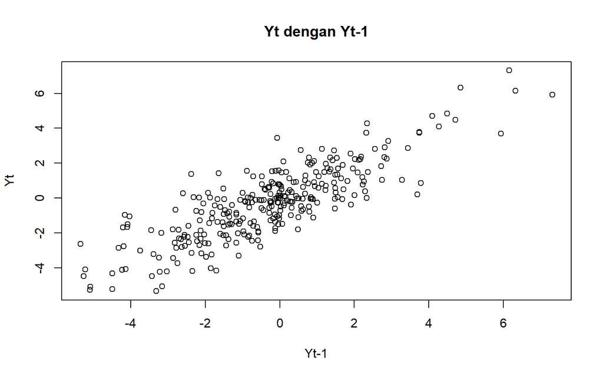

```r
plot(y=yt_arma,
     x=yt_1_arma,
     main="Yt dengan Yt-1",
     xlab="Yt-1",
     ylab="Yt")
```

```r
cor(yt_arma,yt_1_arma)
```

```
## [1] 0.8341053
```

### Korelasi antara Y_t dengan Y_t−2

```r
yt_arma2 <- arma22[-c(1,2)]
yt_arma2
```

```
##   [1] -0.123649649 -0.041842846  0.135461629 -0.304157307  0.624125402
##   [6]  0.623822547 -0.647256701 -0.119028106 -1.741688527 -0.440096612
##  [11] -0.707001192  1.237615803  1.963897796  1.680556494 -0.072143526
##  [16] -1.056728053 -1.332098735 -1.473061112 -0.708164622 -1.596387137
##  [21] -0.521989233 -2.791963110 -0.685609784 -1.353037140 -0.779784335
##  [26] -1.432328070 -2.715678053 -1.828775649 -3.241503094 -3.430016266
##  [31] -4.489018340 -5.215233079 -4.090631845 -1.673006047 -0.063342247
##  [36]  3.438127707  2.867063192  2.256702787  0.945021616  0.682084255
##  [41]  0.257244763  1.131672895  0.819353363  1.908272338 -0.388057229
##  [46]  0.468642746 -0.014416263  0.779324351  2.326750607 -0.011299327
##  [51]  0.019716717  0.124982924  0.101893379  2.091367174  1.457377515
##  [56]  2.718882746  1.819697769  0.972966953  1.490409607  1.327755728
##  [61]  1.501104614  0.313617974 -0.229005577 -0.249763173 -0.273879641
##  [66] -0.570642949 -1.977320916 -3.381804950 -3.215909365 -4.225856619
##  [71] -4.129440435 -4.074201092 -1.502329614 -1.633018122  1.413937794
```

[output cut: 45 more lines]

```r
yt_2_arma <- arma22[-c(299,300)]
yt_2_arma
```

```
##   [1] -0.818846599 -0.543847619 -0.123649649 -0.041842846  0.135461629
##   [6] -0.304157307  0.624125402  0.623822547 -0.647256701 -0.119028106
##  [11] -1.741688527 -0.440096612 -0.707001192  1.237615803  1.963897796
##  [16]  1.680556494 -0.072143526 -1.056728053 -1.332098735 -1.473061112
##  [21] -0.708164622 -1.596387137 -0.521989233 -2.791963110 -0.685609784
##  [26] -1.353037140 -0.779784335 -1.432328070 -2.715678053 -1.828775649
##  [31] -3.241503094 -3.430016266 -4.489018340 -5.215233079 -4.090631845
##  [36] -1.673006047 -0.063342247  3.438127707  2.867063192  2.256702787
##  [41]  0.945021616  0.682084255  0.257244763  1.131672895  0.819353363
##  [46]  1.908272338 -0.388057229  0.468642746 -0.014416263  0.779324351
##  [51]  2.326750607 -0.011299327  0.019716717  0.124982924  0.101893379
##  [56]  2.091367174  1.457377515  2.718882746  1.819697769  0.972966953
##  [61]  1.490409607  1.327755728  1.501104614  0.313617974 -0.229005577
##  [66] -0.249763173 -0.273879641 -0.570642949 -1.977320916 -3.381804950
##  [71] -3.215909365 -4.225856619 -4.129440435 -4.074201092 -1.502329614
```

[output cut: 45 more lines]

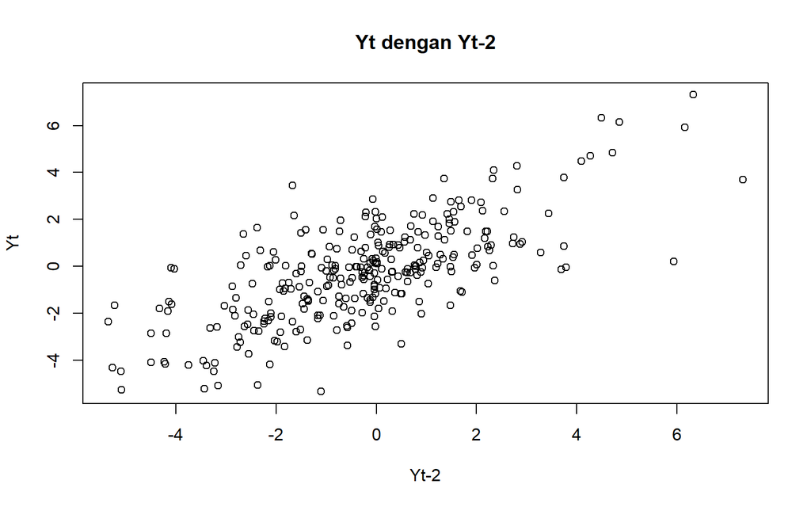

```r
plot(y=yt_arma2,
     x=yt_2_arma,
     main="Yt dengan Yt-2",
     xlab="Yt-2",
     ylab="Yt")
```

```r
cor(yt_arma2,yt_2_arma)
```

```
## [1] 0.7139591
```

### Korelasi antara Y_t dengan Y_t−3

```r
yt_arma3 <- arma22[-c(1,2,3)]
yt_arma3
```

```
##   [1] -0.041842846  0.135461629 -0.304157307  0.624125402  0.623822547
##   [6] -0.647256701 -0.119028106 -1.741688527 -0.440096612 -0.707001192
##  [11]  1.237615803  1.963897796  1.680556494 -0.072143526 -1.056728053
##  [16] -1.332098735 -1.473061112 -0.708164622 -1.596387137 -0.521989233
##  [21] -2.791963110 -0.685609784 -1.353037140 -0.779784335 -1.432328070
##  [26] -2.715678053 -1.828775649 -3.241503094 -3.430016266 -4.489018340
##  [31] -5.215233079 -4.090631845 -1.673006047 -0.063342247  3.438127707
##  [36]  2.867063192  2.256702787  0.945021616  0.682084255  0.257244763
##  [41]  1.131672895  0.819353363  1.908272338 -0.388057229  0.468642746
##  [46] -0.014416263  0.779324351  2.326750607 -0.011299327  0.019716717
##  [51]  0.124982924  0.101893379  2.091367174  1.457377515  2.718882746
##  [56]  1.819697769  0.972966953  1.490409607  1.327755728  1.501104614
##  [61]  0.313617974 -0.229005577 -0.249763173 -0.273879641 -0.570642949
##  [66] -1.977320916 -3.381804950 -3.215909365 -4.225856619 -4.129440435
##  [71] -4.074201092 -1.502329614 -1.633018122  1.413937794  2.164424209
```

[output cut: 45 more lines]

```r
yt_3_arma <- arma22[-c(298,299,300)]
yt_3_arma
```

```
##   [1] -0.818846599 -0.543847619 -0.123649649 -0.041842846  0.135461629
##   [6] -0.304157307  0.624125402  0.623822547 -0.647256701 -0.119028106
##  [11] -1.741688527 -0.440096612 -0.707001192  1.237615803  1.963897796
##  [16]  1.680556494 -0.072143526 -1.056728053 -1.332098735 -1.473061112
##  [21] -0.708164622 -1.596387137 -0.521989233 -2.791963110 -0.685609784
##  [26] -1.353037140 -0.779784335 -1.432328070 -2.715678053 -1.828775649
##  [31] -3.241503094 -3.430016266 -4.489018340 -5.215233079 -4.090631845
##  [36] -1.673006047 -0.063342247  3.438127707  2.867063192  2.256702787
##  [41]  0.945021616  0.682084255  0.257244763  1.131672895  0.819353363
##  [46]  1.908272338 -0.388057229  0.468642746 -0.014416263  0.779324351
##  [51]  2.326750607 -0.011299327  0.019716717  0.124982924  0.101893379
##  [56]  2.091367174  1.457377515  2.718882746  1.819697769  0.972966953
##  [61]  1.490409607  1.327755728  1.501104614  0.313617974 -0.229005577
##  [66] -0.249763173 -0.273879641 -0.570642949 -1.977320916 -3.381804950
##  [71] -3.215909365 -4.225856619 -4.129440435 -4.074201092 -1.502329614
```

[output cut: 45 more lines]

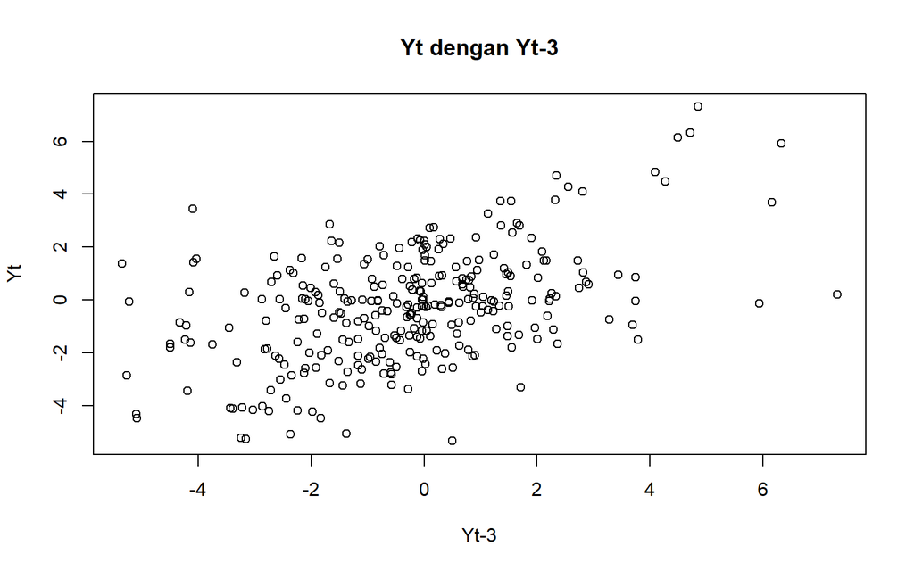

```r
plot(y=yt_arma3,
     x=yt_3_arma,
     main="Yt dengan Yt-3",
     xlab="Yt-3",
     ylab="Yt")
```

```r
cor(yt_arma3,yt_3_arma)
```

```
## [1] 0.4792831
```

## Hitung autokorelasi masing masing baik dari data bangkitan maupun secara teoritis

### Autokorelasi Data Bangkitan

```r
acf_arma <- acf(arma22, lag.max=3, plot=FALSE)

rho1_data <- acf_arma$acf[2]
rho2_data <- acf_arma$acf[3]
rho3_data <- acf_arma$acf[4]

rho1_data
```

```
## [1] 0.8337865
```

```r
rho2_data
```

```
## [1] 0.7132503
```

```r
rho3_data
```

```
## [1] 0.4786168
```

### Autokorelasi Teoritis ARMA(2,2)

```r
phi <- c(0.5,0.2)
theta <- c(0.4,0.6)

acf_teori <- ARMAacf(
  ar=phi,
  ma=theta,
  lag.max=3
)

acf_teori
```

```
##         0         1         2         3
## 1.0000000 0.8591993 0.7491908 0.5464353
```

```r
rho1_teori <- acf_teori[2]
rho2_teori <- acf_teori[3]
rho3_teori <- acf_teori[4]

rho1_teori
```

```
##         1
## 0.8591993
```

```r
rho2_teori
```

```
##         2
## 0.7491908
```

```r
rho3_teori
```

```
##         3
## 0.5464353
```

### Perbandingan

```r
data_autokorelasi <- c(
  rho1_data,
  rho2_data,
  rho3_data
)

teori_autokorelasi <- c(
  rho1_teori,
  rho2_teori,
  rho3_teori
)

hasil <- data.frame(
  Lag=1:3,
  Data_Bangkitan=data_autokorelasi,
  Teoritis=teori_autokorelasi
)

hasil
```

```
##   Lag Data_Bangkitan  Teoritis
## 1   1      0.8337865 0.8591993
## 2   2      0.7132503 0.7491908
## 3   3      0.4786168 0.5464353
```